# Polyphénol - part 2: sortir les QTLs

# 1/ Introduction

This file is a supplementary data attached with the publication. It aims to describe the QTLs found for the metabolomic composites.

Let’s upload the file containing all the LOD scores. It contains about 4M lines, so it is quite long…(~2minutes)

```r
#Watch out, to reproduct analysis, you have to update the path.
data=read.table("~/Dropbox/Publi_Fusariose/ANALYSIS_REPRO/DATA/bilan_simple_marker_metabolomique.gz" , header=T , sep="," )
# random lines of the dataset to develop quicker
data=data[ sample( seq(1,nrow(data)) , 200000 )  , ]
```

Let’s upload the physical position of every genes of the BWr

```r
POS=read.table("/Users/yan/Dropbox/Publi_Fusariose/ANALYSIS_REPRO/DATA/physical_map_of_BW.txt", na.string="-" , header=T , dec=".") ;  colnames(POS)=c( "chromo_BW" ,  "contig" ,"position_BW" )
```

Charge some libraries that will be useful

```r
library(RColorBrewer)
library(xtable)
library(plotly)
library(FactoMineR)
```

Let’s create a color vector for the study

```r
my_colors = brewer.pal(8, "Set2")
my_colors = colorRampPalette(my_colors)(50)
```

How many variables do we have? –> 116 metabolomic variables.

```r
my_carac=levels(data$variable)
nlevels(data$variable)
```

```
## [1] 116
```

Separate 2013 and 2014 analysis

```r
# Year
Y13=my_carac[grep("blup13", my_carac )]
Y14=my_carac[grep("blup14", my_carac )]
```

# 2/ Useful functions

A function to plot a QTL and visualize the LOD scores along the chromosome. Works for several variable on a specific chromosome.

```r
plot_a_QTL=function(data, select_chromo, variable, LOD_threshold, my_ylim){

  # order data
  data=data[ order(data$LG , data$Distance) , ]

  # plot the first variable
  a=data[data$variable==variable[1] & data$LG==select_chromo & !is.na(data$LOD) , ]
  plot(a$LOD ~ a$Distance , type="l" , ylim=c(0,my_ylim) , ylab="LOD score" , xlab="position (cM)" , col=my_colors[1] , lwd=1.6 )

  # for every other variable, add a LOD score
  num=1
  for( i in c(2:length(variable))){
    num=num+1
    a=data[data$variable==variable[num] & data$LG==select_chromo & !is.na(data$LOD) , ]
    points(a$LOD ~a$Distance , type="l" , ylim=c(0,my_ylim) , ylab="LOD score" , xaxt="n" , col=my_colors[num] , lwd=1.6 )
    }

  # add lod threshold
  abline(h=3.61 , col="grey")

  # add legend
  #legend("topright" , horiz=F , col=my_colors[c(1:length(variable))] , legend=variable , bty="n" , lty=1 , pt.cex=2, lwd=1.6)
  #legend("topleft" , horiz=F , col="white" , legend=select_chromo , bty="n" , lty=1 , pt.cex=0, lwd=1.6)

  }
```

A function to summarize all the significant QTL. Gives the max LOD score, the IC, the position etc..

```r
summary_table_for_QTL=function(data, selected_variable, LOD_threshold, size_IC){

  # order data
  data=data[ order(data$LG , data$Distance) , ]
  my_colors=brewer.pal(5,"Paired")

  # create empty summary table
  bil=data.frame(matrix(0,1000,9))
  colnames(bil)=c("pop","carac","chromo","LOD_max","position","marker","IC","R2","a")

  # loop to study every variable & chromosome
  num_line_bilan=0
    num_chromo=0

    for(chrom in levels(data$LG)){
        num_variable=0
        num_col=0
        num_chromo=num_chromo+1

        for(var in selected_variable){
            num_col=num_col+1
            current_data=data[ data$variable==var & data$LG==chrom  , ]
            current_data=current_data[!is.na(current_data$LOD) , ]
            signif_data=current_data[ current_data$LOD > LOD_threshold  , ]

            #Si j'ai des marqueurs significatifs
            if(nrow(signif_data)>0){

                #Je récupère les infos de ce QTL
                LOD_max=max(signif_data$LOD)
                mark_max=signif_data$marqueur[signif_data$LOD==LOD_max]
                pos_max=signif_data$Distance[signif_data$LOD==LOD_max]
                r2_max=signif_data$R2[signif_data$LOD==LOD_max]
                a_max=signif_data$a[signif_data$LOD==LOD_max]

                #Détermination IC --> je bloque la zone max a 30 cM
                in_IC=current_data[ current_data$LOD > (LOD_max-size_IC) & current_data$Distance > (pos_max-30) & current_data$Distance < (pos_max+30)  , ]
                IC_min=min(round(in_IC$Distance,2))
                IC_max=max(round(in_IC$Distance,2))

                #Je remplie le tableau bilan
                num_line_bilan=num_line_bilan+1
                bil[num_line_bilan , 1]="DS"
                bil[num_line_bilan , 2]=var
                bil[num_line_bilan , 3]=chrom
                bil[num_line_bilan , 4]=LOD_max
                bil[num_line_bilan , 5]=pos_max[1]
                bil[num_line_bilan , 6]=as.character(mark_max)[1]
                bil[num_line_bilan , 7]=paste(IC_min, IC_max, sep="-")
                bil[num_line_bilan , 8]=r2_max[1]
                bil[num_line_bilan , 9]=a_max[1]

                #close 3 loops
                }}}

# Clean and print the Table
bil=bil[bil$pop!=0 , ]
bil=bil[ order(bil$pop , bil$chromo , bil$carac) , ]
return(bil)
#close function
}
```

# 3/ Determine LOD threshold

```
cd /NAS/g2pop/HOLTZ_YAN_DATA/DIC2_SILUR/QTL/PUBLI
for i in 4 7 10 13 16 ; do echo $i ; Rscript /NAS/g2pop/HOLTZ_YAN_DATA/programmes/Calculate_LOD_threshold.R genotypage.csv phenotypage.csv carte $i ; done
more tmp.o*  |  grep -A4 "AR1"
```

# 4/ Table of significant QTLs

## 2013

How many metabolomic variable do we have in 2013?

```r
length(Y13)
```

```
## [1] 58
```

Let’s summarize in a table every significant QTL for 2013.

```r
summary_QTL_13=summary_table_for_QTL(data, Y13, 3.61, 1.5)
summary_QTL_13=summary_QTL_13[ order(summary_QTL_13$chromo, summary_QTL_13$LOD_max, decreasing = T) , ]
```

| pop | carac | chromo | LOD_max | position | marker | IC | R2 | a |
| --- | --- | --- | --- | --- | --- | --- | --- | --- |
| DS | X7d_360_blup13 | 6B | 4.26 | 176.90 | Traes_6BL_A0879077D@708 | 176.9-178.9 | 9.18 | 10.82 |
| DS | X4_280_blup13 | 6B | 3.69 | 137.20 | Traes_6BL_5EFDFD374@5248 | 137.2-137.2 | 7.90 | 1.85 |
| DS | X10d_360_blup13 | 5A | 3.75 | 315.00 | Traes_5AL_710CB4163@1787 | 315-315 | 8.02 | 29.33 |
| DS | X4d_320_blup13 | 4B | 4.04 | 118.50 | Traes_4BL_39BDB67AA@298 | 109-121.2 | 8.69 | 1.67 |
| DS | X4_280_blup13 | 4B | 3.88 | 55.90 | Cluster_8092\|Contig4\|original@1648 | 50.8-58.8 | 8.32 | 4.81 |
| DS | X8_360_blup13 | 4B | 3.76 | 37.30 | Traes_4BS_A834E1175@2651 | 26.7-51.5 | 8.04 | 2.07 |
| DS | X4d_320_blup13 | 4A | 3.70 | 205.50 | Traes_4AL_2F1590BC5@435 | 195.3-214.2 | 7.90 | 1.55 |
| DS | X1d_280_blup13 | 3B | 4.09 | 217.60 | Cluster_460\|Contig12\|likelySeq@1159 | 214.3-222.6 | 8.79 | 2.45 |
| DS | X22_360_blup13 | 2A | 6.83 | 228.50 | Cluster_14172\|Contig6\|original@337 | 228.5-228.5 | 14.65 | 2.01 |
| DS | X6d_280_blup13 | 2A | 5.87 | 83.30 | Traes_2AS_F89BE725A@1040 | 83.3-86.1 | 12.66 | 9.50 |
| DS | X17_360_blup13 | 2A | 4.58 | 163.70 | Cluster_12083\|Contig1\|original@4740 | 160.9-163.7 | 9.89 | 1.17 |
| DS | X8d_360_blup13 | 1B | 28.63 | 6.00 | Traes_1BS_4073CE3DB@2375 | 6-6 | 44.00 | 21.97 |
| DS | X10d_360_blup13 | 1B | 25.53 | 2.40 | Traes_1BS_B9CBEFAE5@3469 | 2.4-2.4 | 41.10 | 116.29 |
| DS | X33_360_blup13 | 1B | 24.33 | 2.40 | Traes_1BS_B9CBEFAE5@3427 | 2.4-2.4 | 39.90 | 9.09 |
| DS | X9d_360_blup13 | 1B | 22.59 | 2.40 | Cluster_14459\|Contig3\|original@598 | 2.4-2.4 | 38.07 | 31.16 |
| DS | X31_360_blup13 | 1B | 22.20 | 2.00 | Cluster_1882\|Contig7\|original@596 | 2-2 | 37.64 | 8.80 |
| DS | X16_360_blup13 | 1B | 21.46 | 2.40 | Traes_1BS_B9CBEFAE5@2995 | 2.4-2.4 | 36.81 | 3.60 |
| DS | X3d_360_blup13 | 1B | 21.23 | 2.40 | Traes_1BS_B9CBEFAE5@3412 | 2.4-5.1 | 36.55 | 173.24 |
| DS | X35_360_blup13 | 1B | 19.77 | 2.40 | Traes_1BS_B9CBEFAE5@3346 | 2.4-2.4 | 34.85 | 7.49 |
| DS | X29_360_blup13 | 1B | 19.65 | 2.40 | Cluster_7051\|Contig3\|original@221 | 2.4-2.4 | 34.71 | 27.13 |
| DS | ISOVIT_blup13 | 1B | 19.65 | 6.00 | Traes_1BS_4A63D1DBC@1544 | 2.4-6 | 34.70 | 16.40 |
| DS | X30_360_blup13 | 1B | 19.27 | 2.40 | Traes_1BS_B9CBEFAE5@3220 | 2.4-2.4 | 34.25 | 3.30 |
| DS | X36_360_blup13 | 1B | 18.77 | 2.40 | Traes_1BS_B9CBEFAE5@2995 | 2.4-2.4 | 33.62 | 8.90 |
| DS | X5d_360_blup13 | 1B | 18.73 | 2.40 | Cluster_7051\|Contig3\|original@221 | 2.4-2.4 | 33.57 | 159.99 |
| DS | X2d_360_blup13 | 1B | 18.53 | 2.40 | Traes_1BS_B9CBEFAE5@3469 | 2.4-2.4 | 33.32 | 41.02 |
| DS | HOMOO_blup13 | 1B | 16.98 | 5.10 | Traes_1BS_4073CE3DB@2213 | 5.1-6 | 31.33 | 46.99 |
| DS | X4d_360_blup13 | 1B | 16.73 | 5.10 | Traes_1BS_4073CE3DB@2075 | 5.1-6 | 30.99 | 9.25 |
| DS | X11d_360_blup13 | 1B | 15.79 | 6.00 | Traes_1BS_4073CE3DB@1748 | 6-6 | 29.70 | 18.40 |
| DS | X1d_360_blup13 | 1B | 15.34 | 5.10 | Traes_1BS_4073CE3DB@2660 | 5.1-5.1 | 29.06 | 387.14 |
| DS | X14_360_blup13 | 1B | 14.80 | 2.40 | Traes_1BS_B9CBEFAE5@1271 | 2.4-2.4 | 28.28 | 5.40 |
| DS | X28_360_blup13 | 1B | 14.23 | 5.10 | Traes_1BS_4073CE3DB@2075 | 5.1-5.1 | 27.46 | 5.39 |
| DS | X11_360_blup13 | 1B | 14.12 | 2.40 | Traes_1BS_B9CBEFAE5@3220 | 1.6-2.4 | 27.29 | 6.50 |
| DS | X1d_320_blup13 | 1B | 13.57 | 2.40 | Traes_1BS_B9CBEFAE5@3469 | 2.4-2.4 | 26.47 | 4.68 |
| DS | X23_360_blup13 | 1B | 13.38 | 6.00 | Traes_1BS_4073CE3DB@2252 | 5.1-6 | 26.18 | 2.90 |
| DS | X32_360_blup13 | 1B | 11.56 | 5.10 | Traes_1BS_4073CE3DB@2288 | 5.1-6 | 23.29 | 3.47 |
| DS | X1_360_blup13 | 1B | 10.38 | 2.40 | Traes_1BS_B9CBEFAE5@3469 | 2.4-12.8 | 21.29 | 16.50 |
| DS | X17_360_blup13 | 1B | 9.12 | 5.10 | Traes_1BS_4A63D1DBC@1537 | 5.1-6 | 19.05 | 1.50 |
| DS | X6d_360_blup13 | 1B | 8.90 | 5.10 | Traes_1BS_4073CE3DB@2702 | 5.1-6 | 18.64 | 5.72 |
| DS | X2_360_blup13 | 1B | 8.43 | 2.40 | Traes_1BS_B9CBEFAE5@3220 | 2.4-12.2 | 17.77 | 6.88 |
| DS | X6_320_blup13 | 1B | 7.74 | 2.40 | Cluster_7051\|Contig3\|original@221 | 2.4-2.4 | 16.44 | 4.68 |
| DS | X2d_320_blup13 | 1B | 7.50 | 5.10 | Traes_1BS_4073CE3DB@2075 | 2.4-6 | 15.98 | 14.53 |
| DS | X22_360_blup13 | 1B | 7.14 | 2.40 | Cluster_7051\|Contig3\|original@221 | 2.4-5.1 | 15.27 | 2.17 |
| DS | X25_360_blup13 | 1B | 6.89 | 2.40 | Traes_1BS_B9CBEFAE5@3469 | 2-2.4 | 14.77 | 2.68 |
| DS | X7d_360_blup13 | 1B | 6.44 | 6.00 | Traes_1BS_4073CE3DB@1683 | 6-15.5 | 13.86 | 15.13 |
| DS | X24_360_blup13 | 1B | 6.16 | 6.00 | Traes_1BS_2F6DD776E@391 | 6-6 | 13.27 | 2.35 |
| DS | X3_360_blup13 | 1B | 4.92 | 6.00 | Traes_1BS_4073CE3DB@1748 | 5.1-12.2 | 10.64 | 3.78 |
| DS | Orient_blup13 | 1B | 4.71 | 2.40 | Traes_1BS_B9CBEFAE5@3427 | 2.4-17.9 | 10.17 | 9.51 |
| DS | p.COUM_blup13 | 1B | 4.64 | 5.10 | Traes_1BS_4073CE3DB@2678 | 5.1-14.1 | 10.03 | 3.23 |
| DS | X3d_320_blup13 | 1B | 4.52 | 5.10 | Traes_1BS_4A63D1DBC@1582 | 5.1-12.8 | 9.75 | 3.24 |
| DS | X10_360_blup13 | 1B | 3.87 | 22.40 | Traes_1BS_06F3A2D5D@411 | 1.2-23.3 | 8.31 | 4.81 |

OK so we have a lot of QTL actually! How many QTL do we have?

```r
nrow(summary_QTL_13)
```

```
## [1] 50
```

On which chromosomes are these QTLs?

|  | V1 |
| --- | --- |
| 1B | 39 |
| 2A | 3 |
| 3B | 1 |
| 4A | 1 |
| 4B | 3 |
| 5A | 1 |
| 6B | 2 |

It is quite crazy to see how many QTLs are on the 1B chromosome! (Where we have a good fusariose QTL also)

Let’s plot this 1B QTL with only the significant metabolomic variables. Quite impressing! That’s a huge QTL, exactly in the same place that the fusariose one.

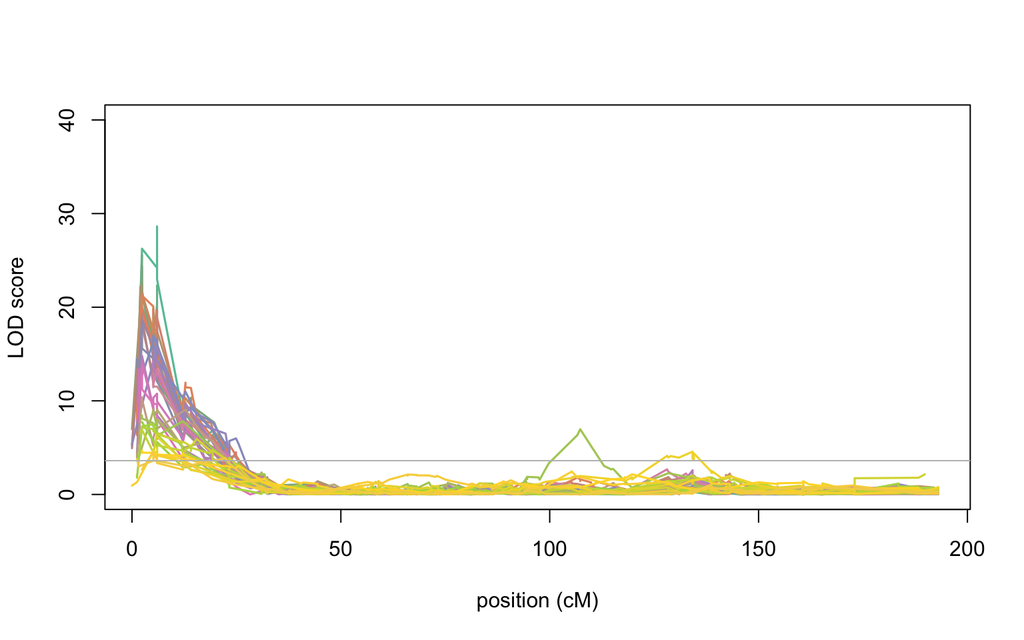

```r
#Chromosome 1B
to_plot=summary_QTL_13$carac[summary_QTL_13$chromo=="1B"]
plot_a_QTL(data, "1B", to_plot, 3.61, 40)
```

## 2014

How many metabolomic variable do we have in 2014?

```r
length(Y14)
```

```
## [1] 58
```

Let’s summarize in a table every significant QTL for 2014.

```r
summary_QTL_14=summary_table_for_QTL(data, Y14, 3.61, 1.5)
summary_QTL_14=summary_QTL_14[ order(summary_QTL_14$chromo, summary_QTL_14$LOD_max, decreasing = T) , ]
```

| pop | carac | chromo | LOD_max | position | marker | IC | R2 | a |
| --- | --- | --- | --- | --- | --- | --- | --- | --- |
| DS | X7_280_blup14 | 7A | 4.84 | 34.90 | Cluster_7131\|Contig2\|original@99 | 32.7-34.9 | 18.66 | 100.51 |
| DS | X10_320_blup14 | 6A | 3.91 | 89.40 | Cluster_41152\|Contig1\|less_than_5_individuals\|original@225 | 80.2-89.4 | 15.26 | 3.78 |
| DS | p.COUM_blup14 | 5B | 4.68 | 188.20 | Traes_5BL_635B0AB02@1153 | 175.2-211.6 | 18.09 | 3.45 |
| DS | X1d_280_blup14 | 5B | 4.43 | 210.10 | Traes_5BL_D699B2815@1220 | 198.5-226.1 | 17.18 | 3.30 |
| DS | X1d_360_blup14 | 5B | 3.76 | 283.80 | Traes_5BL_FF6260428@727 | 283.8-283.8 | 14.67 | 215.76 |
| DS | X1d_320_blup14 | 5A | 3.72 | 190.20 | Traes_5AL_9FBA88E19@496 | 190.2-203.8 | 14.52 | 4.00 |
| DS | X9_320_blup14 | 3B | 4.64 | 13.50 | Cluster_14693\|Contig1\|original@260 | 11.8-30.2 | 17.93 | 2.67 |
| DS | X3d_320_blup14 | 3B | 3.76 | 59.00 | Cluster_298\|Contig1\|original@1971 | 58-59 | 14.66 | 9.29 |
| DS | X4d_360_blup14 | 1B | 51.71 | 2.40 | Traes_1BS_B9CBEFAE5@3427 | 2.4-2.4 | 73.90 | 12.12 |
| DS | X10d_360_blup14 | 1B | 50.29 | 2.40 | Traes_1BS_B9CBEFAE5@3469 | 2.4-2.4 | 73.35 | 136.66 |
| DS | HOMOO_blup14 | 1B | 41.07 | 5.10 | Traes_1BS_4073CE3DB@2075 | 5.1-5.1 | 69.11 | 60.34 |
| DS | X8d_360_blup14 | 1B | 40.34 | 2.40 | Traes_1BS_B9CBEFAE5@1271 | 2.4-2.4 | 68.71 | 29.04 |
| DS | X11d_360_blup14 | 1B | 37.97 | 5.10 | Traes_1BS_4073CE3DB@2288 | 5.1-5.1 | 67.36 | 23.43 |
| DS | X1d_360_blup14 | 1B | 37.87 | 5.10 | Traes_1BS_4073CE3DB@3055 | 5.1-5.1 | 67.30 | 516.59 |
| DS | X1_360_blup14 | 1B | 36.04 | 5.10 | Cluster_16778\|Contig1\|original@1840 | 5.1-5.1 | 66.17 | 29.33 |
| DS | ISOVIT_blup14 | 1B | 30.36 | 5.10 | Traes_1BS_4073CE3DB@2213 | 5.1-5.1 | 62.11 | 19.06 |
| DS | X9d_360_blup14 | 1B | 26.05 | 5.10 | Traes_1BS_4073CE3DB@1580 | 5.1-5.1 | 58.32 | 28.36 |
| DS | X5d_360_blup14 | 1B | 25.16 | 6.00 | Cluster_65\|Contig1\|original@152 | 6-6 | 57.43 | 156.68 |
| DS | X31_360_blup14 | 1B | 23.63 | 2.40 | Cluster_7051\|Contig3\|original@221 | 2.4-5.1 | 55.85 | 6.21 |
| DS | X3d_360_blup14 | 1B | 23.08 | 2.40 | Traes_1BS_B9CBEFAE5@2995 | 2.4-2.4 | 55.24 | 237.74 |
| DS | X2d_360_blup14 | 1B | 22.38 | 5.10 | Traes_1BS_4073CE3DB@2213 | 2.4-6 | 54.44 | 39.49 |
| DS | X28_360_blup14 | 1B | 20.15 | 5.10 | Traes_1BS_4073CE3DB@2657 | 5.1-5.1 | 51.72 | 7.10 |
| DS | X33_360_blup14 | 1B | 19.74 | 6.00 | Traes_1BS_4073CE3DB@2375 | 5.1-6 | 51.19 | 6.59 |
| DS | X11_360_blup14 | 1B | 19.15 | 6.00 | Traes_1BS_2F6DD776E@391 | 6-6 | 50.37 | 8.93 |
| DS | X29_360_blup14 | 1B | 17.75 | 5.10 | Traes_1BS_4073CE3DB@3055 | 5.1-5.1 | 48.40 | 21.82 |
| DS | X2_360_blup14 | 1B | 14.07 | 6.00 | Traes_1BS_4073CE3DB@1748 | 5.1-6 | 42.34 | 12.51 |
| DS | Orient_blup14 | 1B | 13.66 | 5.10 | Traes_1BS_4073CE3DB@1728 | 5.1-6 | 41.57 | 10.63 |
| DS | X16_360_blup14 | 1B | 13.47 | 6.00 | Traes_1BS_4073CE3DB@2252 | 5.1-12.8 | 41.19 | 3.12 |
| DS | X14_360_blup14 | 1B | 11.96 | 2.40 | Cluster_14459\|Contig3\|original@598 | 2.4-2.4 | 38.19 | 6.75 |
| DS | X32_360_blup14 | 1B | 10.61 | 2.40 | Traes_1BS_B9CBEFAE5@1271 | 2.4-6 | 35.20 | 2.07 |
| DS | X7d_360_blup14 | 1B | 10.27 | 5.10 | Traes_1BS_4073CE3DB@2660 | 2.4-6 | 34.41 | 33.94 |
| DS | X36_360_blup14 | 1B | 9.87 | 5.10 | Traes_1BS_4A63D1DBC@1537 | 2.4-12.8 | 33.46 | 3.24 |
| DS | X1d_320_blup14 | 1B | 8.97 | 5.10 | Traes_1BS_4073CE3DB@2657 | 5.1-6 | 31.21 | 5.66 |
| DS | X3_360_blup14 | 1B | 8.85 | 6.00 | Traes_1BS_2F6DD776E@391 | 1.2-6 | 30.88 | 3.82 |
| DS | X23_360_blup14 | 1B | 8.70 | 5.10 | Traes_1BS_4A63D1DBC@1537 | 2.4-5.1 | 30.49 | 2.48 |
| DS | X35_360_blup14 | 1B | 8.70 | 6.00 | Traes_1BS_2F6DD776E@390 | 5.1-14.1 | 30.48 | 2.48 |
| DS | X25_360_blup14 | 1B | 7.58 | 5.10 | Traes_1BS_4073CE3DB@2213 | 5.1-5.1 | 27.41 | 4.41 |
| DS | X6d_360_blup14 | 1B | 7.09 | 6.00 | Traes_1BS_4073CE3DB@1748 | 2.4-14.1 | 25.97 | 6.42 |
| DS | X30_360_blup14 | 1B | 6.83 | 5.10 | Traes_1BS_4073CE3DB@2702 | 5.1-6 | 25.20 | 1.41 |
| DS | X10_360_blup14 | 1B | 6.19 | 2.40 | Traes_1BS_B9CBEFAE5@3469 | 2.4-12.8 | 23.19 | 6.68 |
| DS | X2d_320_blup14 | 1B | 6.16 | 5.10 | Traes_1BS_4073CE3DB@3099 | 2.4-6 | 23.10 | 20.49 |
| DS | X17_360_blup14 | 1B | 4.51 | 6.00 | Traes_1BS_2F6DD776E@391 | 2.4-6 | 17.44 | 1.03 |
| DS | X22_360_blup14 | 1B | 4.49 | 5.10 | Traes_1BS_4073CE3DB@1580 | 1.2-19.3 | 17.40 | 1.76 |
| DS | X8_360_blup14 | 1B | 4.18 | 5.10 | Traes_1BS_4073CE3DB@2678 | 5.1-5.1 | 16.27 | 3.29 |
| DS | X1_280_blup14 | 1B | 3.65 | 111.40 | Traes_1BL_A2DA07F32@1441 | 107.3-134.5 | 14.26 | 3.45 |

OK so we have a lot of QTL actually! How many QTL do we have?

```r
nrow(summary_QTL_14)
```

```
## [1] 45
```

On which chromosomes are these QTLs?

|  | V1 |
| --- | --- |
| 1B | 37 |
| 3B | 2 |
| 5A | 1 |
| 5B | 3 |
| 6A | 1 |
| 7A | 1 |

It is quite crazy to see how many QTLs are on the 1B chromosome! (Where we have a good fusariose QTL also)

Let’s plot this 1B QTL with only the significant metabolomic variables. Quite impressing! That’s a huge QTL, exactly in the same place that the fusariose one.

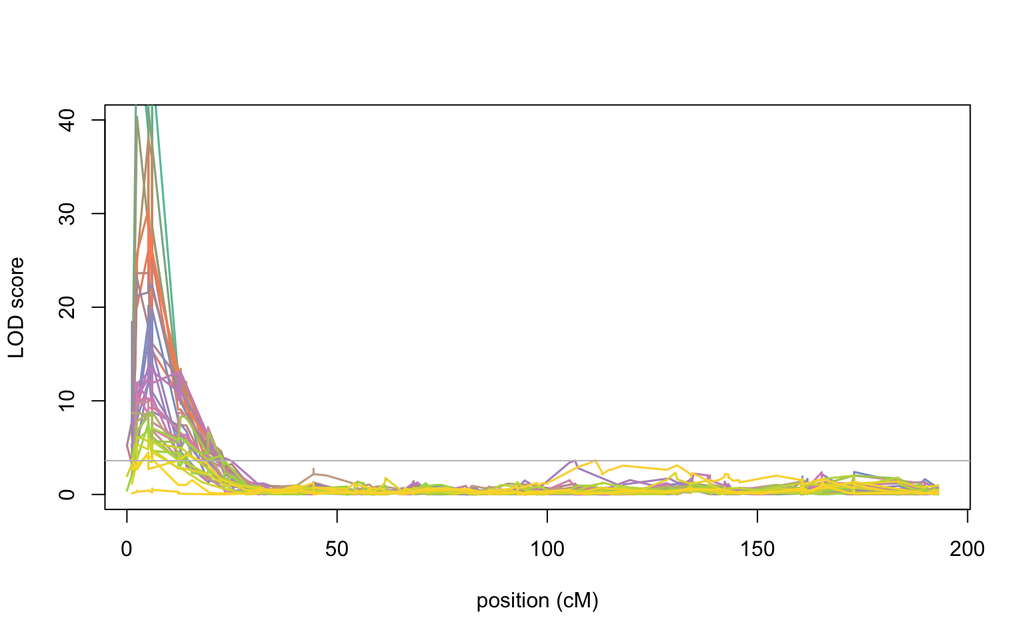

```r
#Chromosome 1B
to_plot=summary_QTL_14$carac[summary_QTL_14$chromo=="1B"]
plot_a_QTL(data, "1B", to_plot, 3.61, 40)
```

# 5/ Conclusion

Il existe 58 composé phénoliques étudiés. Parmis eux, 23 sont clairement exprimés chez dic2, et 16 sont clairement exprimés chez silur.

La totalité des composés présent chez Dic2 et pas chez silur sont controlés par le QTL 1B. (23 sur 23 les 2 années). Parmis les 16 présent chez Silur, seul 8 (resp. 9) sont controlés par le QTL1B en 2013 (resp. 2014)

Ce QTL colocalise très précisemment avec un QTL majeur détecté dans nos données d’observations de la résistance à la fusariose. Ce QTL a la particularité d’avoir comme allèle apportant la résistance l’allèle de SILUR.

Yan Holtz

October 2016